# Descriptive Statistics

Gabriel and David

2024-11-30

## Biostatistics Clinic

### Importing Data

A data scientist will rarely have such luck and will have to import data into R from either a file, a database, or some other source. To do this, you’ll need to have your data correctly formatted and saved in a file format that R is able to recognise. Fortunately for us, R is able to recognise a wide variety of file formats, although in reality you’ll probably end up only using two or three regularly.

We will briefly describe the key approach and function, in case you want to use your new knowledge on one of your own datasets.

#### Paths and the Working Directory

The first step is to find the file containing your data and know its *path*. When you are working in R it is useful to know your *working directory*. This is the folder in which R will save or look for files by default. You can see your working directory by typing:

```r
getwd()
```

You can also change your working directory using the function `setwd`. Or you can change it through RStudio by clicking on “Session”.

#### Import functions

Once you’ve saved your data file in a suitable format we can now read this file into R. The workhorse function for importing data into R is the `read.table()` function (we discuss some alternatives later in the chapter). The `read.table()` function is a very flexible function with a shed load of arguments (see `?read.table`) but it’s quite simple to use. Let’s import a *tab delimited* file called `children_data.txt` which contains the data on hours of TV watch per week. The file is located in a `R Bootcamp2024` directory which itself is located in our *root directory*. The first row of the data contains the variable (column) names. To use the `read.table()` function to import this file

We have included the children_data in a TxT and CSV files as example datasets in our working directory.

```r
children_data <- read.table(file = 'children_data.txt', header = TRUE, sep = "\t",
                        stringsAsFactors = TRUE)
```

```r
str(children_data)
```

```
## 'data.frame':    150 obs. of  6 variables:
##  $ No      : int  1 2 3 4 5 6 7 8 9 10 ...
##  $ age     : Factor w/ 4 levels "11-13","2-4",..: 4 4 2 3 1 2 2 1 1 4 ...
##  $ gender  : Factor w/ 2 levels "Female","Male": 2 2 2 1 1 2 1 2 1 1 ...
##  $ location: Factor w/ 3 levels "Rural Town","Suburban Neighborhood",..: 3 3 1 3 2 1 1 1 1 3 ...
##  $ income  : Factor w/ 4 levels "High Income",..: 1 2 1 1 1 4 2 1 3 2 ...
##  $ hours   : int  12 12 19 28 22 11 29 10 24 7 ...
```

There are a few things to note about the above command. First, the *file path* and the *filename* (including the *file extension*) needs to be enclosed in either single or double quotes (i.e. the `children_data.txt` bit) as the `read.table()` function expects this to be a *character string*. If your working directory is already set to the directory which contains the file, you don’t need to include the entire file path just the *filename* as in our case. In the example above, the file path was not included but if the data is not stored in the working directory then the *entire file path* is separated with a single forward slash `/`. This will work regardless of the operating system you are using and we recommend you stick with this.

However, Windows users may be more familiar with the single backslash notation and if you want to keep using this you will need to include them as double backslashes. Note though that the double backslash notation will not work on computers using Mac OSX or Linux operating systems.

```r
children_data2 <- read.table(file = 'children_data.txt',
                      header = TRUE, sep = "\t", stringsAsFactors = TRUE)
```

The `header = TRUE` argument specifies that the first row of your data contains the variable names (i.e. “age”, “gender”, etc). If this is not the case you can specify `header = FALSE` (actually, this is the default value so you can omit this argument entirely). The `sep = "\t"` argument tells R that the file delimiter is a `tab (\t)`.

We can use the `str()` function to return a compact and informative summary of your data frame.

```r
str(children_data)
```

```
## 'data.frame':    150 obs. of  6 variables:
##  $ No      : int  1 2 3 4 5 6 7 8 9 10 ...
##  $ age     : Factor w/ 4 levels "11-13","2-4",..: 4 4 2 3 1 2 2 1 1 4 ...
##  $ gender  : Factor w/ 2 levels "Female","Male": 2 2 2 1 1 2 1 2 1 1 ...
##  $ location: Factor w/ 3 levels "Rural Town","Suburban Neighborhood",..: 3 3 1 3 2 1 1 1 1 3 ...
##  $ income  : Factor w/ 4 levels "High Income",..: 1 2 1 1 1 4 2 1 3 2 ...
##  $ hours   : int  12 12 19 28 22 11 29 10 24 7 ...
```

Notice also that the *character string* variables (“age”, “gender”, “location” and “income”) have been imported as factors because we used the argument `stringsAsFactors = TRUE`. If this is not what you want you can prevent this by using the `stringsAsFactors = FALSE` or from R version 4.0.0 you can just leave out this argument as `stringsAsFactors = FALSE` is the default.

```r
children_data3 <- read.table(file = 'children_data.txt', header = TRUE, sep = "\t", stringsAsFactors = FALSE)
```

```r
str(children_data3)
```

```
## 'data.frame':    150 obs. of  6 variables:
##  $ No      : int  1 2 3 4 5 6 7 8 9 10 ...
##  $ age     : chr  "8-10" "8-10" "2-4" "5-7" ...
##  $ gender  : chr  "Male" "Male" "Male" "Female" ...
##  $ location: chr  "Urban City" "Urban City" "Rural Town" "Urban City" ...
##  $ income  : chr  "High Income" "Low Income" "High Income" "High Income" ...
##  $ hours   : int  12 12 19 28 22 11 29 10 24 7 ...
```

If we just wanted to see the names of our variables (columns) in the data frame we can use the `names()` function which will return a character vector of the variable names.

```r
names(children_data)
```

```
## [1] "No"       "age"      "gender"   "location" "income"   "hours"
```

`R` has a number of variants of the `read.table()` function that you can use to import a variety of file formats. The most useful of these are the `read.csv()`, `read.csv2()` and `read.delim()` functions. The `read.csv()` function is used to import comma separated value `(.csv)` files and assumes that the data in columns are separated by a comma (it sets `sep = ","` by default). It also assumes that the first row of the data contains the *variable names* by default (it sets `header = TRUE` by default). The `read.csv2()` function assumes data are separated by semicolons and that a comma is used instead of a decimal point (as in many European countries). The `read.delim()` function is used to import `tab delimited` data and also assumes that the first row of the data contains the *variable names* by default.

```r
# import .csv file
child_data1 <- read.csv(file = 'children_data.csv')

# import .csv file with dec = "," and sep = ";"
child_data2 <- read.csv2(file = 'children_data.csv')

#correct by introducing sep = ","
child_data22 <- read.csv2(file = 'children_data.csv', sep = ",")

# import tab delim file with sep = "\t"
child_data3 <- read.delim(file = 'children_data.txt')
```

If you want your variables to be factors (categorical) instead, you can use the argument `stringsAsFactors = TRUE`:

```r
child_data1 <- read.csv("children_data.csv", stringsAsFactors = TRUE)
str(child_data1)
```

```
## 'data.frame':    150 obs. of  6 variables:
##  $ No      : int  1 2 3 4 5 6 7 8 9 10 ...
##  $ age     : Factor w/ 4 levels "11-13","2-4",..: 4 4 2 3 1 2 2 1 1 4 ...
##  $ gender  : Factor w/ 2 levels "Female","Male": 2 2 2 1 1 2 1 2 1 1 ...
##  $ location: Factor w/ 3 levels "Rural Town","Suburban Neighborhood",..: 3 3 1 3 2 1 1 1 1 3 ...
##  $ income  : Factor w/ 4 levels "High Income",..: 1 2 1 1 1 4 2 1 3 2 ...
##  $ hours   : int  12 12 19 28 22 11 29 10 24 7 ...
```

```r
#child<-read.csv(file.choose())
```

### Other import options

There are numerous other functions to import data from a variety of sources and formats. Most of these functions are contained in packages that you will need to install before using them. We list a couple of the more useful packages and functions below.

Various functions from the `readr` package are also very efficient at reading in large data files. The `readr` package is part of the `tidyverse` collection of packages and provides many equivalent functions to base R for importing data. The `readr` functions are used in a similar way to the `read.table()` or `read.csv()` functions and many of the arguments are the same (see `?readr::read_table` for more details). There are however some differences. For example, when using the `read_table()` function the `header = TRUE` argument is replaced by `col_names = TRUE` and the function returns a tibble class object which is the `tidyverse` equivalent of a `data.frame` object.

```r
library(readr)
# import white space delimited files
all_data1 <- read_table(file = 'children_data.txt', col_names = TRUE)
# import comma delimited files
all_data2 <- read_csv(file = 'children_data.csv')

# import tab delimited files
all_data3 <- read_delim(file = 'children_data.txt', delim = "\t")

# or use
all_data4 <- read_tsv(file = 'children_data.txt' )
```

#### Key Functions:

1. `summary()`: Provides a concise overview of the data, including minimum, 1st quartile, median, mean, 3rd quartile, and maximum values.
2. `mean()`: Calculates the average value of a numeric vector.
3. `median()`: Finds the middle value in a sorted numeric vector.
4. `min()` and `max()`: Determine the smallest and largest values, respectively.
5. `sd()`: Computes the standard deviation, a measure of data dispersion.
6. `var()`: Calculates the variance, another measure of data dispersion.
7. `quantile()`: Returns specific quantiles (e.g., quartiles, percentiles) of the data.
8. `IQR()`: Calculates the interquartile range, a measure of variability.

To perform the above functions, we will use the dataset named *health_data*. Let read the *health_data.csv* into our rstudio.

```r
health_data<-read.csv("health_data.csv")
head(health_data)
```

```
##   age    sex marital_status      BMI heart_rate smoking cholesterol sugar_level
## 1  77   Male       Divorced 15.41691   61.09371      No    1.305494    6.961192
## 2  21 Female       Divorced 26.94934   67.03996      No    6.899286    6.456828
## 3  33 Female       Divorced 23.57606   65.80720      No    7.323540    4.672859
## 4  64   Male       Divorced 21.69310   61.38038      No    4.271697    3.903171
## 5  67   Male        Married 22.83780   72.12018      No    4.429661    1.873586
## 6  43   Male         Single 26.72059   61.40978      No    1.979511    8.550551
##   BP_systolic BP_diastolic wealth_index exercise_score_hrs
## 1         121           73            2                8.2
## 2         115           82            5                6.0
## 3         115           75            0               10.6
## 4         113           85            4                6.3
## 5         132           79            0                5.9
## 6         122           84            3                7.2
```

```r
summary(health_data)
```

```
##       age            sex            marital_status          BMI
##  Min.   : 0.00   Length:2500        Length:2500        Min.   : 7.546
##  1st Qu.:30.00   Class :character   Class :character   1st Qu.:21.631
##  Median :40.00   Mode  :character   Mode  :character   Median :24.916
##  Mean   :40.01                                         Mean   :24.970
##  3rd Qu.:50.00                                         3rd Qu.:28.365
##  Max.   :88.00                                         Max.   :43.207
##    heart_rate       smoking           cholesterol         sugar_level
##  Min.   : 33.24   Length:2500        Min.   : 0.000803   Min.   : 0.08086
##  1st Qu.: 63.11   Class :character   1st Qu.: 3.856062   1st Qu.: 4.45568
##  Median : 69.75   Mode  :character   Median : 5.165527   Median : 5.65817
##  Mean   : 69.92                      Mean   : 5.212602   Mean   : 5.65027
##  3rd Qu.: 76.93                      3rd Qu.: 6.609712   3rd Qu.: 6.84602
##  Max.   :108.09                      Max.   :12.709037   Max.   :11.46124
##   BP_systolic     BP_diastolic     wealth_index   exercise_score_hrs
##  Min.   : 85.0   Min.   : 59.00   Min.   :0.000   Min.   : 0.000
##  1st Qu.:113.0   1st Qu.: 76.00   1st Qu.:1.000   1st Qu.: 4.900
##  Median :120.0   Median : 80.00   Median :2.000   Median : 6.900
##  Mean   :120.3   Mean   : 79.96   Mean   :2.481   Mean   : 6.974
##  3rd Qu.:127.0   3rd Qu.: 84.00   3rd Qu.:4.000   3rd Qu.: 9.000
##  Max.   :157.0   Max.   :100.00   Max.   :5.000   Max.   :16.600
```

```r
mean(health_data$age)
```

```
## [1] 40.01
```

```r
mean(health_data$BMI)
```

```
## [1] 24.96969
```

```r
median(health_data$age)
```

```
## [1] 40
```

```r
median(health_data$BMI)
```

```
## [1] 24.91596
```

```r
min(health_data$age)
```

```
## [1] 0
```

```r
max(health_data$age)
```

```
## [1] 88
```

```r
sd(health_data$age)
```

```
## [1] 15.03174
```

```r
var(health_data$age)
```

```
## [1] 225.9531
```

```r
quantile(health_data$age)
```

```
##   0%  25%  50%  75% 100%
##    0   30   40   50   88
```

```r
IQR(health_data$age)
```

```
## [1] 20
```

### Data Wrangling

The term **data wrangling** refers to the processes of *transforming* or *manipulating* raw data into a useful format for downstream analysis and visualization.

Wrangling is an important part of data science, because data rarely comes in precisely the form that suits some particular analysis. For example, you might want to focus only on specific rows or columns of your data, or calculate summary statistics only for specific subgroups. Maybe you want to create a new variable derived from existing ones. Or else you just want to sort the rows according to some variable, to make a table a little easier to read. All of these tasks involve wrangling your data.

The `tidyverse` and `dplyr` libraries, come equipped with several handy data verbs that streamline these wrangling tasks. In this session, you’ll learn to:

- use six key data verbs (summarize, group_by, mutate, filter, select, and arrange) to transform your data into a more convenient form.
- calculate complex summary statistics for arbitrary subsets of your data and combinations of variables.

Let’s, create a code chunk, and then load the `tidyverse`, `dplyr`, and `dslabs` libraries.

```r
# install.packages("tidyverse", "dplyr", "dslabs") # This line of code will allow you to install these packages
library(tidyverse)
library(dplyr)
library(dslabs)
data(murders)
```

This packages introduce functions that perform the most common operations in data wrangling and uses names for these functions that are relatively easy to remember. For example, to change the data table by adding a new column, we use `mutate`. To filter the data table to a subset of rows we use `filter` and to subset the data by selecting specific columns we use `select`. We can also perform a series of operations. For example, select and then filter, by sending the results of one function to another using what is called the *pipe operator*: `%>%`. Some details are included below.

Before we start wrangling let’s look at our data using the command `head()`.

```r
head(murders)
```

```
##        state abb region population total
## 1    Alabama  AL  South    4779736   135
## 2     Alaska  AK   West     710231    19
## 3    Arizona  AZ   West    6392017   232
## 4   Arkansas  AR  South    2915918    93
## 5 California  CA   West   37253956  1257
## 6   Colorado  CO   West    5029196    65
```

### Adding a column with `mutate`

We want all the necessary information for our analysis to be included in the data table. So the first task is to add the murder rate to our data frame. The function mutate takes the data frame as a first argument and the name and values of the variable in the second using the convention `name = values`. So to add murder rate we use:

```r
murders <- mutate(murders, murder_rate = total / population * 100000)
```

Note that here we used `total` and `population` in the function, which are objects that are **not** defined in our workspace. What is happening is that `mutate` knows to look for these variables in the `murders` data frame because the first argument we put was the `murders` data frame. We can see the new column is added:

```r
head(murders)
```

```
##        state abb region population total murder_rate
## 1    Alabama  AL  South    4779736   135    2.824424
## 2     Alaska  AK   West     710231    19    2.675186
## 3    Arizona  AZ   West    6392017   232    3.629527
## 4   Arkansas  AR  South    2915918    93    3.189390
## 5 California  CA   West   37253956  1257    3.374138
## 6   Colorado  CO   West    5029196    65    1.292453
```

Also note that we have over-written the original `murders` object. However, this does *not* change the object that is saved and loaded with `data(murders)`. If we load the `murders` data again, the original will over-write our mutated version.

### Subsetting with `filter`

Now suppose that we want to filter the data table to only show the entries for which the murder rate is lower than 0.71. To do this we use the `filter` function which takes the data table as an argument and then the conditional statement as the next argument. Like mutate, we can use the data table variable names inside the function and it will know we mean the columns and not objects in the workspace.

```r
filter(murders, murder_rate <= 0.71)
```

```
##           state abb        region population total murder_rate
## 1        Hawaii  HI          West    1360301     7   0.5145920
## 2          Iowa  IA North Central    3046355    21   0.6893484
## 3 New Hampshire  NH     Northeast    1316470     5   0.3798036
## 4  North Dakota  ND North Central     672591     4   0.5947151
## 5       Vermont  VT     Northeast     625741     2   0.3196211
```

### Selecting columns with `select`

Although our data table only has six columns, some data tables include hundreds. If we want to view just a few, we can use the `select` function. In the code below we select three columns, assign this to a new object and then filter the new object:

```r
new_table <- select(murders, state, region, murder_rate)
filter(new_table, murder_rate <= 0.71)
```

```
##           state        region murder_rate
## 1        Hawaii          West   0.5145920
## 2          Iowa North Central   0.6893484
## 3 New Hampshire     Northeast   0.3798036
## 4  North Dakota North Central   0.5947151
## 5       Vermont     Northeast   0.3196211
```

### The pipe: `%>%`

In the code above we wanted to show the three variables for states that have murder rates below 0.71. To do this we defined an intermediate object. In `dplyr` we can write code that looks more like our description of what we want to:

> > original data $\rightarrow$ select $\rightarrow$ filter

For such an operation, we can use the pipe `%>%`. The code looks like this:

```r
murders %>% select(state, region, murder_rate) %>% filter(murder_rate <= 0.71)
```

```
##           state        region murder_rate
## 1        Hawaii          West   0.5145920
## 2          Iowa North Central   0.6893484
## 3 New Hampshire     Northeast   0.3798036
## 4  North Dakota North Central   0.5947151
## 5       Vermont     Northeast   0.3196211
```

### Summarizing data with `dplyr`

An important part of exploratory data analysis is summarizing data. It is sometimes useful to split data into groups before summarizing.

### Summarize

The `summarize` function in `dplyr` provides a way to compute summary statistics with intuitive and readable code. We can compute the average of the murder rates like this.

```r
murders %>% summarize(avg = mean(murder_rate))
```

```
##        avg
## 1 2.779125
```

However, note that the US murder rate is **not** the average of the state murder rates. Because in this computation the small states are given the same weight as the large ones. The US murder rate is proportional to the total US murders divided by the total US population.

To compute the country’s average murder rate using the `summarize` function, we can do the following:

```r
us_murder_rate <- murders %>%
  summarize(murder_rate = sum(total) / sum(population) * 100000)

us_murder_rate
```

```
##   murder_rate
## 1    3.034555
```

### Using the dot to access the piped data

The `us_murder_rate` object defined above represents just one number. Yet we are storing it in a data frame

```r
class(us_murder_rate)
```

```
## [1] "data.frame"
```

since, as with most `dplyr` functions, `summarize` *always returns a data frame*.

This might be problematic if we want to use the result with functions that require a numeric value. Here we show a useful trick to access values stored in data piped via `%>%`: when a data object is piped it can be accessed using the dot `.`. To understand what we mean take a look at this line of code:

```r
us_murder_rate %>% .$murder_rate
```

```
## [1] 3.034555
```

Note that this returns the value in the `murder_rate` column of `us_murder_rate` making it equivalent to `us_murder_rate$murder_rate`. To understand this line, you just need to think of `.` as a placeholder for the data that is being passed through the pipe. Because this data object is a data frame, we can access it’s columns with the `$`.

To get a number from the original data table with one line of code we can type:

```r
us_murder_rate <- murders %>%
  summarize( murder_rate = sum(total) / sum(population) * 100000) %>%
  .$murder_rate

us_murder_rate
```

```
## [1] 3.034555
```

which is now a numeric:

```r
class(us_murder_rate)
```

```
## [1] "numeric"
```

### Group then summarize

A common operation in data exploration is to first split data into groups and then compute summaries for each group. For example, we may want to compute the median murder rate for each region. The `group_by` function helps us do this.

If we type this:

```r
murders %>%
  group_by(region) %>%
  summarize(median_rate = median(murder_rate))
```

```
## # A tibble: 4 × 2
##   region        median_rate
##   <fct>               <dbl>
## 1 Northeast            1.80
## 2 South                3.40
## 3 North Central        1.97
## 4 West                 1.29
```

we get a table with the median murde rate for each of the four regions.

### Sorting data tables

When examining a dataset it is often convenient to sort the table by the different columns. We know about the `order` and `sort` functions, but for ordering entire tables, the `dplyr` function `arrange` is useful. For example, here we order the states by population size:

```r
murders %>%
  arrange(population) %>%
  head()
```

```
##                  state abb        region population total murder_rate
## 1              Wyoming  WY          West     563626     5   0.8871131
## 2 District of Columbia  DC         South     601723    99  16.4527532
## 3              Vermont  VT     Northeast     625741     2   0.3196211
## 4         North Dakota  ND North Central     672591     4   0.5947151
## 5               Alaska  AK          West     710231    19   2.6751860
## 6         South Dakota  SD North Central     814180     8   0.9825837
```

Note that we get to decide which column to sort by. To see the states by murder rate, from smallest to largest, we arrange by `murder_rate` instead:

```r
murders %>%
  arrange(murder_rate) %>%
  head()
```

```
##           state abb        region population total murder_rate
## 1       Vermont  VT     Northeast     625741     2   0.3196211
## 2 New Hampshire  NH     Northeast    1316470     5   0.3798036
## 3        Hawaii  HI          West    1360301     7   0.5145920
## 4  North Dakota  ND North Central     672591     4   0.5947151
## 5          Iowa  IA North Central    3046355    21   0.6893484
## 6         Idaho  ID          West    1567582    12   0.7655102
```

Note that the default behavior is to order in ascending order. In `dplyr`, the function `desc` transforms a vector to be in descending order. So if we want to sort the table in descending order we can type

```r
murders %>%
  arrange(desc(murder_rate)) %>%
  head()
```

```
##                  state abb        region population total murder_rate
## 1 District of Columbia  DC         South     601723    99   16.452753
## 2            Louisiana  LA         South    4533372   351    7.742581
## 3             Missouri  MO North Central    5988927   321    5.359892
## 4             Maryland  MD         South    5773552   293    5.074866
## 5       South Carolina  SC         South    4625364   207    4.475323
## 6             Delaware  DE         South     897934    38    4.231937
```

#### Nested Sorting

If we are ordering by a column with ties we can use a second column to break the tie. Similarly, a third column can be used to break ties between the first and second and so on. Here we order by `region` then within region we order by murder rate:

```r
murders %>%
  arrange(region, murder_rate) %>%
  head()
```

```
##           state abb    region population total murder_rate
## 1       Vermont  VT Northeast     625741     2   0.3196211
## 2 New Hampshire  NH Northeast    1316470     5   0.3798036
## 3         Maine  ME Northeast    1328361    11   0.8280881
## 4  Rhode Island  RI Northeast    1052567    16   1.5200933
## 5 Massachusetts  MA Northeast    6547629   118   1.8021791
## 6      New York  NY Northeast   19378102   517   2.6679599
```

#### Rename

Renaming a variable in a data frame in R is surprisingly hard to do! The `rename()` function is designed to make this process easier.

Here you can see the names of the variables in the `murders` data frame.

```r
names(murders)
```

```
## [1] "state"       "abb"         "region"      "population"  "total"
## [6] "murder_rate"
```

Let’s assume that we want to rename the `abb` column to `abbreviation`, here is how we can do it

```r
murders <- murders %>% rename(abbreviation = abb)
names(murders)
```

```
## [1] "state"        "abbreviation" "region"       "population"   "total"
## [6] "murder_rate"
```

The syntax inside the `rename()` function is to have the new name on the left-hand side of the `=` sign and the old name on the right-hand side.

Let return back to our *health_data* and calculate some descriptive statistics using the `dplyr` functions.

```r
stats<-health_data%>%group_by(sex)%>%
  summarise(mean_age=mean(age), mean_bmi=mean(BMI), mean_heart.rate=mean(heart_rate),sd_age=sd(age), sd_bmi=sd(BMI), sd_heart.rate=sd(heart_rate) )
stats
```

```
## # A tibble: 2 × 7
##   sex    mean_age mean_bmi mean_heart.rate sd_age sd_bmi sd_heart.rate
##   <chr>     <dbl>    <dbl>           <dbl>  <dbl>  <dbl>         <dbl>
## 1 Female     39.9     24.8            70.1   15.2   5.15         10.5
## 2 Male       40.1     25.1            69.8   14.8   5.03          9.90
```

```r
stats<-health_data%>%group_by(sex)%>%
  summarise(mean_age=mean(age), mean_bmi=mean(BMI), mean_heart.rate=mean(heart_rate),sd_age=sd(age), sd_bmi=sd(BMI), sd_heart.rate=sd(heart_rate) )%>%.$mean_age

stats
```

```
## [1] 39.88055 40.13719
```

## Basic plots

Exploratory data visualization is perhaps the strength of R. One can quickly go from idea to data to plot with a unique balance of flexibility and ease. For example, Excel may be easier than R but it is no where near as flexible. D3 may be more flexible and powerful than R, but it takes much longer to generate a plot. The next section is dedicated to this topic, but here we introduce some very basic plotting functions.

### Scatter plots

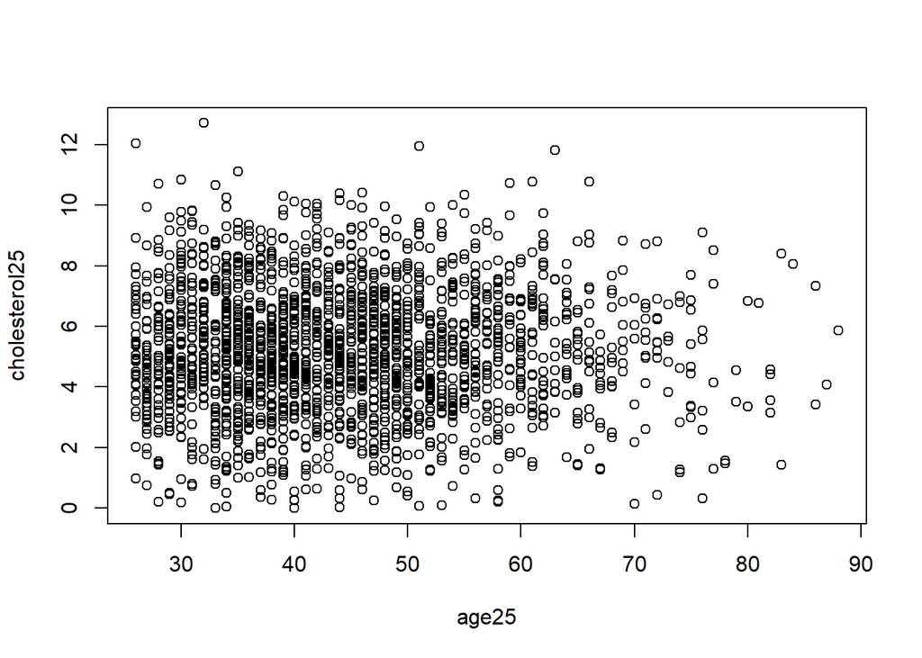

```r
health_sub<-health_data%>%filter(age>25)
age25<-health_sub$age
cholesterol25<-health_sub$cholesterol
bmi25<-health_sub$BMI
plot(age25, cholesterol25)
```

Can see any relationship?

**Advanced**: For a quick plot that avoids accessing variables twice, we can use the `with` function

```r
with(health_sub, plot(age, cholesterol))
```

### Histograms

We will describe histograms as they relate to distributions in the next section. Here we will simply note that histograms are a powerful graphical summary of a list of numbers that gives you a general overview of the types of values you have. We can make a histogram of our *Exercise score* by simply typing

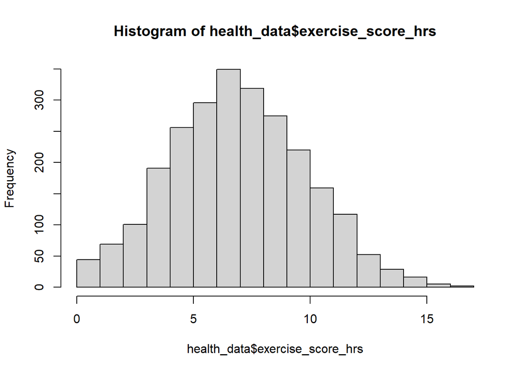

```r
hist(health_data$exercise_score_hrs)
```

### Boxplot

Boxplots provide a more terse summary than the histogram - but they are easier to stack with other boxplots. Here we can use them to compare the different groups.

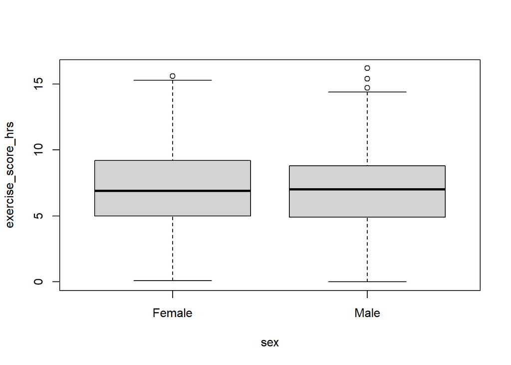

```r
boxplot(exercise_score_hrs~ sex, data = health_sub)
```